# Question

La siguiente grafica muestra la evolucion de la poblacion de cinco paises entre 1960 y 2013:

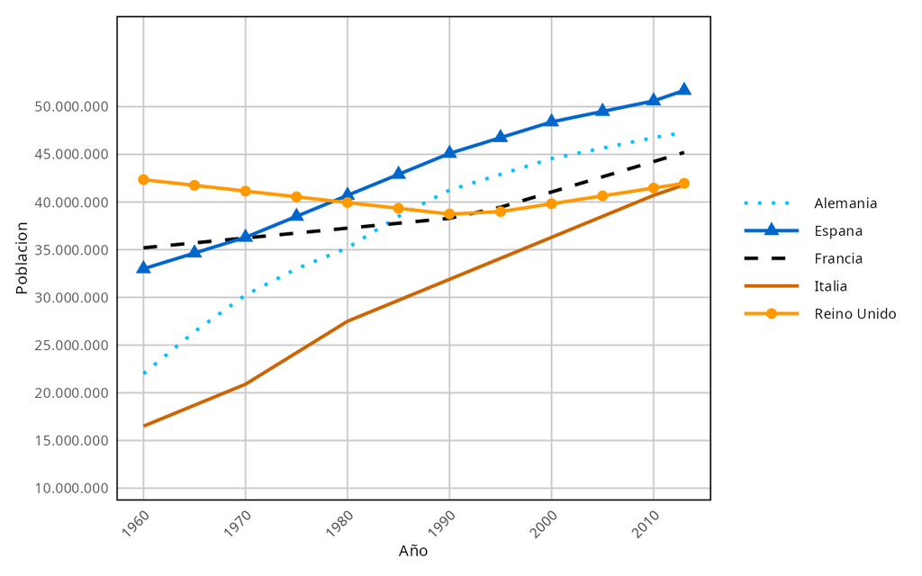

Segun la grafica, ¿en que año aproximadamente la poblacion de Francia igualo a la de Reino Unido?

## Answerlist

- 1994
- 1988
- 1992
- 1995

# Solution

Para determinar el año en que las poblaciones se igualan, debemos identificar el punto donde las lineas correspondientes se cruzan en la grafica.

Analisis del cruce:

1. En 1960, Reino Unido (aproximadamente 42 millones) esta por encima de Francia (aproximadamente 35 millones)
2. Francia crece mas rapidamente que Reino Unido
3. Las lineas se cruzan aproximadamente en **1992**
4. Despues de este punto, Francia supera a Reino Unido

Por lo tanto, la respuesta correcta es **1992**.

## Answerlist

- Incorrecto
- Incorrecto
- Correcto
- Incorrecto

# Meta-information

exname: series_temporales_poblacion_aleatorio_interpretacion_representacion_n2_v1 extype: schoice exsolution: 0010 exshuffle: FALSE # icfes: # competencia: interpretacion_representacion # nivel_dificultad: 2 # componente: aleatorio